# Practicals2

Spatial Filters

1) Correlation and Convolutions

2) Vector Representation of Linear Filtering

3) Smoothing Spatial Filters

- 3.1) Averaging Linear filter (Mean)
- 3.2) Order Statistics filter (Median)  
  3.3) Gaussian filter

4) Sharpening Spatial Filters

- First Derivative Filters

  Sobel Filter  
  Prewitt Filter  
  Canny Filter
- Second Derivative Filters

  Laplacian Filter  
  Laplacian of Gaussian Filter

3) MIN and MAX Filter

### **Correlattion and Convolution**

```python
import cv2
from google.colab.patches import cv2_imshow
import numpy as np
import scipy.ndimage
import matplotlib.pyplot as plt
```

[figure not shown]

```
original_image             correlation_filtering           convolution_filtering
```

[figure not shown]

```
True
```

```python
src = cv2.imread('Cameraman.png', 0)

# prepare averaging filter
kernel = np.ones((3, 3), dtype=np.float32)

# apply kernel to the original image
kernel /= 9
dst = cv2.filter2D(src, -1, kernel)

# concatenate images horizontally
result = np.concatenate((src, dst), axis=1)

cv2_imshow(result)
cv2.imwrite('output1.jpeg',result)  #writing the image

from scipy import ndimage# read image
# prepare the filter
src = cv2.imread('Cameraman.png',0)

# apply kernel to the original image using convolution filtering
kernel = np.array([[1,1,1],[1,1,0],[1,0,0]])
dst_conv  = ndimage.convolve(src, kernel, mode='constant', cval=1.0)

# apply kernel to the original image using correlation filtering
dst_corr = cv2.filter2D(src, -1, kernel)# concatenate images horizontally
result = np.concatenate((src, dst_corr, dst_conv), axis=1)

print("\n")
print("original_image     ","       correlation_filtering      ","    convolution_filtering")

# Displaying the results
cv2_imshow(result)
cv2.imwrite('output2.jpeg',result)  #writing the image
```

### **Vector Representation of Linear Filtering**

```
different types of images
```

[figure not shown]

```python
def point_operation(img, K, L):  #function for [point operation]

    #Applies point operation to given grayscale image
    img = np.asarray(img, dtype=np.float)
    img = img*K + L

    # clip pixel values
    img[img > 255] = 255
    img[img < 0] = 0
    return np.asarray(img, dtype = np.int)

def main():
    # read an image
    img = cv2.imread('lena.png')  #reading the image
    gray = cv2.cvtColor(img, cv2.COLOR_BGR2GRAY)  #converting to gray scale image

    # k = 0.5, l = 0
    out1 = point_operation(gray, 0.5, 0)
    # k = 1., l = 10
    out2 = point_operation(gray, 1., 10)
    # k = 0.8, l = 15
    out3 = point_operation(gray, 0.7, 25)

    res = np.hstack([gray,out1, out2, out3]) #stacking all the images into one image and printing
    plt.imshow(res, cmap='gray')
    plt.axis('off')
    print("different types of images")
    plt.show() #printing the image
    #cv2.imwrite('output1.jpeg',res)  #writing the image
if __name__ == '__main__':
    main()
```

**Smoothing Spatial Filters**

3.1) Averaging Linear filter (Mean)

3.2) Order Statistics filter (Median)

3.3) Gaussian filter </b>

Mean Filter

```
Original Image                 Mean filtered image
```

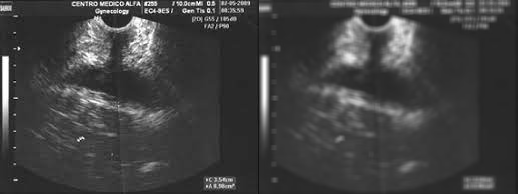

```
True
```

```python
# Opening the image using cv2.
a = cv2.imread('ultrasound_muscle.png')

# Converting the image to grayscale.
a = cv2.cvtColor(a, cv2.COLOR_BGR2GRAY)

# Initializing the filter of size 5 by 5.
# The filter is divided by 25 for normalization.
k = np.ones((5,5))/25

# performing convolution
b = scipy.ndimage.filters.convolve(a, k)

# Displaying the original image and mean filtered image
res = np.hstack((a,b))

print("Original Image       ","         Mean filtered image")
cv2_imshow(res)

# Writing b to a file.
cv2.imwrite('mean_output.png', res)
```

Median Filter

```
Original Image             Median filtered image
```

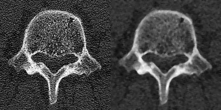

```
True
```

```python
# Opening the image and converting it to grayscale.
a = cv2.imread('ct_saltandpepper.png')

# Converting the image to grayscale.
a = cv2.cvtColor(a, cv2.COLOR_BGR2GRAY)

# Performing the median filter.
b = scipy.ndimage.filters.median_filter(a, size=5)

# Displaying the original image and median filtered image
res = np.hstack((a,b))

print("Original Image     ","       Median filtered image")
cv2_imshow(res)

# Saving b as median_output.png in Figures folder
cv2.imwrite('median_output.png', res)
```

The median filter efficiently removed the salt-and-pepper noise.

Gaussian filter

```
Original Image             Gaussian filtered image
```

[figure not shown]

```
True
```

```python
# applying the guassian blur on the image
gauss = cv2.GaussianBlur(a,(51,51),0)


# Displaying the original image and gaussian filtered image
res = np.hstack((a,gauss))

print("Original Image     ","       Gaussian filtered image")
cv2_imshow(res)

# Saving b as median_output.png in Figures folder
cv2.imwrite('median_output.png', res)
```

*First Derivative Filters*

A derivative filter adds noise to an image.

1) Sobel Filter

2) Prewitt Filter

3) Canny Filter

1) Sobel Filter

The Sobel filter or mask is used to find horizontal and vertical edges.

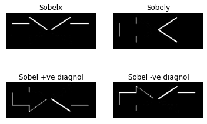

```python
# PREWITT

img = cv2.imread("BlackWhite.png")

ker1 = np.array(   [  [-1,-2,-1], # horizontal edge detection
                      [ 0, 0, 0],
                      [ 1, 2, 1]])

ker2 = np.array(   [  [-1, 0, 1], # vertical edge detection
                      [-2, 0, 2],
                      [-1, 0, 1]])

ker3 = np.array(   [  [ 0, 1, 2], # +ve diagnol edge detection
                      [-1, 0, 1],
                      [-2, -1,0]])

ker4 = np.array(   [  [-2, -1, 0], # -ve diagnol edge detection
                      [-1, 0, 1],
                      [ 0, 1, 2]])

# applying the above filters on the image.
prewittx   =  cv2.filter2D(img,-1,ker1)
prewitty   =  cv2.filter2D(img,-1,ker2)
prew_diag1 =  cv2.filter2D(img,-1,ker3)
prew_diag2 =  cv2.filter2D(img,-1,ker4)


# displaying the images in (2,2) subplot
plt.subplot(2,2,1),plt.imshow(prewittx,cmap = 'gray')
plt.title('Sobelx'), plt.xticks([]), plt.yticks([])

plt.subplot(2,2,2),plt.imshow(prewitty,cmap = 'gray')
plt.title('Sobely'), plt.xticks([]), plt.yticks([])

plt.subplot(2,2,3),plt.imshow(prew_diag1,cmap = 'gray')
plt.title('Sobel +ve diagnol'), plt.xticks([]), plt.yticks([])

plt.subplot(2,2,4),plt.imshow(prew_diag2,cmap = 'gray')
plt.title('Sobel -ve diagnol'), plt.xticks([]), plt.yticks([])

plt.show()
```

2) Prewitt Filter

Another popular first derivative filter is Prewitt.  
However, the filter does not reduce noise like the Sobel filter.

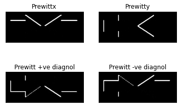

```python
# PREWITT

img = cv2.imread("BlackWhite.png")

ker1 = np.array(   [  [-1,-1,-1], # horizontal edge detection
                      [ 0, 0, 0],
                      [ 1, 1, 1]])

ker2 = np.array(   [  [-1, 0, 1], # vertical edge detection
                      [-1, 0, 1],
                      [-1, 0, 1]])

ker3 = np.array(   [  [ 0, 1, 1], # +ve diagnol edge detection
                      [-1, 0, 1],
                      [-1, -1,0]])

ker4 = np.array(   [  [-1, -1, 0], # -ve diagnol edge detection
                      [-1, 0, 1],
                      [ 0, 1, 1]])

# applying the above filters on the image.
prewittx   =  cv2.filter2D(img,-1,ker1)
prewitty   =  cv2.filter2D(img,-1,ker2)
prew_diag1 =  cv2.filter2D(img,-1,ker3)
prew_diag2 =  cv2.filter2D(img,-1,ker4)


# displaying the images in (2,2) subplot
plt.subplot(2,2,1),plt.imshow(prewittx,cmap = 'gray')
plt.title('Prewittx'), plt.xticks([]), plt.yticks([])

plt.subplot(2,2,2),plt.imshow(prewitty,cmap = 'gray')
plt.title('Prewitty'), plt.xticks([]), plt.yticks([])

plt.subplot(2,2,3),plt.imshow(prew_diag1,cmap = 'gray')
plt.title('Prewitt +ve diagnol'), plt.xticks([]), plt.yticks([])

plt.subplot(2,2,4),plt.imshow(prew_diag2,cmap = 'gray')
plt.title('Prewitt -ve diagnol'), plt.xticks([]), plt.yticks([])

plt.show()
```

*Canny Filter*

Another popular filter for edge detection is the Canny filter or Canny edge detector.

```python
import cv2

# Opening the image.
a = cv2.imread('BlackWhite.png')
print(a.shape)
# Performing Canny edge filter.
b = cv2.Canny(a, 100, 200)

#cv2_imshow(a)
cv2_imshow(b)

# Saving b.
cv2.imwrite('../Figures/canny_output.png', b)
```

[output not shown]

```
(86, 218, 3)
```

```
False
```

*Second Derivative Filters*

**Laplacian Filter**

One of the most popular second derivative filters is the Laplacian.

[figure not shown]

```
True
```

```python
# Opening the image.
a = cv2.imread('Cameraman.png')

# Performing Laplacian filter.
b = ndimage.filters.laplace(a,mode='reflect')

res = np.hstack((a,b))
cv2_imshow(res)

cv2.imwrite('laplacian_Cameraman.png',b)
```

a derivative filter adds noise to an image.

The effect is magnified when the first derivative image is differentiated again (to obtain a second derivative) as in the case of second derivative filters. The above Figure displays this effect.

As there are several edges in the input image, the Laplacian filter over-segments the object (creates many edges) as seen in the output, Figure (b). This results in a noisy image with no discernible edges.

**Laplacian of Gaussian Filter**

To offset the noise effect from the Laplacian, a smoothing function, Gaussian, is used along with the Laplacian.  
While the Laplacian calculates the zero-crossing and determines the edges, the Gaussian smooths the noise induced by the second derivative.

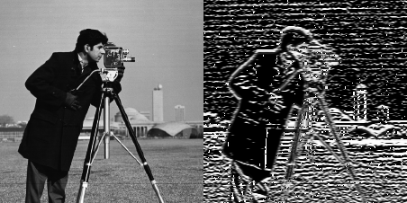

```
True
```

```python
# Opening the image.
a = cv2.imread('Cameraman.png')

# Performing Laplacian filter.
b = ndimage.filters.gaussian_laplace(a, sigma=1,mode='reflect')

res = np.hstack((a,b))
cv2_imshow(res)

cv2.imwrite('gaussian_laplacian_Cameraman.png',b)
```

**MAX Filter**

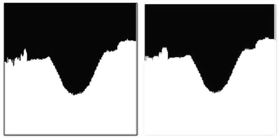

```
True
```

```python
# Opening the image and converting it to grayscale.
a = cv2.imread('wave1.png')

# Converting the image to grayscale.
a = cv2.cvtColor(a, cv2.COLOR_BGR2GRAY)
a = cv2.resize(a,(200,200))


# Performing the median filter.
b = scipy.ndimage.filters.maximum_filter(a, size=5)
b = cv2.resize(b,(200,200))

# Displaying the original image and median filtered image
res = np.hstack((a,b))
cv2_imshow(res)

# Saving b as median_output.png in Figures folder
cv2.imwrite('max_output.png', res)
```

After application of the max filter, the white pixels have grown and hence the thin edges in the input image are replaced by white pixels in the output image as shown in Figure(b).

**MIN FILTER**

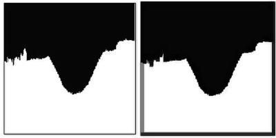

```
True
```

```python
# Opening the image and converting it to grayscale.
a = cv2.imread('wave1.png')

# Converting the image to grayscale.
a = cv2.cvtColor(a, cv2.COLOR_BGR2GRAY)
a = cv2.resize(a,(200,200))

# Performing the median filter.
b = scipy.ndimage.filters.minimum_filter(a, size=5)
b = cv2.resize(b,(200,200))

# Displaying the original image and median filtered image
res = np.hstack((a,b))
cv2_imshow(res)

# Saving b as median_output.png in Figures folder
cv2.imwrite('minimum_output.png', res)
```

After application of the min filter to the input image in left figure, the black pixels have grown and hence the thin edges in the input image are thicker in the output image as shown in Figure.